# Obstacle Detection Users Guide

# Overview

This lab demonstrates the use of TI mmWave sensors to detect objects that are within close proximity of a vehicle. Using the AWR1642-ODS EVM, algorithms run onboard the single-chip device to create Range-Azimuth and Range-Elevation heatmaps, then performs object detection with CFAR, angle of arrival estimation and clustering on configured range rows in the heatmaps.

[figure not shown]

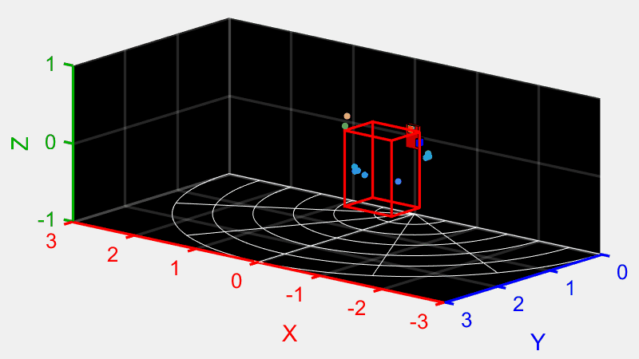

# Quickstart

The quickstart contains:

- Precompiled binaries for flashing the device using Uniflash
- Visualizer as .exe

## 1. Hardware and Software Requirements

### Hardware

| Item | Details |
| --- | --- |
| Device | [AWR1642 ODS EVM](http://www.ti.com/tool/AWR1642BOOST-ODS) |
| Computer | PC with Windows 7 or 10. If a laptop is used, please use the ‘High Performance’ power plan in Windows. 2.4Ghz processor, 8GB RAM recommended. |
| Micro USB Cable | USB 2.0 to Micro USB. |
| Power Supply | 5V, >2.5A with 2.1-mm barrel jack (center positive). The power supply can be wall adapter style or a battery pack with a USB to barrel jack cable. |

### Software

| Tool | Version | Required For | Details |
| --- | --- | --- | --- |
| MATLAB Runtime | 2017a (9.2) | GUI Visualizer | To run the quickstart visualizer the [runtime](https://www.mathworks.com/products/compiler/matlab-runtime.html) is sufficient. |
| TI mmWave SDK | 2.0.0.4 | Firmware Source Code | The latest [TI mmWave SDK](https://www.ti.com/tool/MMWAVE-SDK) and all the related tools are required to be installed as specified in the mmWave SDK release notes |
| TI Emulators package | 6.0.0576.0 or later | - | Upgrade to the latest using CCS update process (see SDK user guide for more details) |
| ODS Design Document | n/a | More Details /Info | [TI Design](http://www.ti.com/tool/TIDEP-0104) |

## 2. Physical Setup

For best results, the EVM should be positioned at car door height, with no objects in the configured range of the sensor except those objects that are under test:

[figure not shown]

In order to provide +/-70deg FOV in azimuth and +/-40deg FOV in elevation, the AWR1642BOOST-ODS EVM must be placed with antenna at the top as shown in this picture.

[figure not shown]

## 3. Flash the Device

- Power on the EVM using a 5V/2.5A power supply.
- Flash the following image using **Uniflash**

| Image | Location |
| --- | --- |
| Meta Image 1/RadarSS | `<TOOLBOX_INSTALL_DIR>\source\ti\examples\Automotive_Body_Sensors\obstacle_detection\prebuilt_binaries\odsdemo_16xx.bin` |

Steps for flashing via uniflash can be found here

## 4. Run the Lab Visualizer

| Program File | Purpose |
| --- | --- |
| ods_3d_visualizer.m | Running within Matlab |
| ods_3d_visualizer.exe | Running from a DOS command window |

- The following steps assume the AWR1642-ODS EVM is flashed with the Obstacle Detection firmware.
- Mount the EVM as shown above in the Test Setups.
- Attach the micro USB cable from the EVM to the host PC.
- Attach the 5V power adapter cable to the EVM.
- Open a DOS Command Window, and cd to `<TOOLBOX_INSTALL_DIR>\tools\visualizers\Automotive_Obstacle_Detection_GUI`.
- At the DOS prompt, enter this command: (there are no command line arguments)
  - ods_3d_visualizer
- After a moment, the visualizer will look like this:

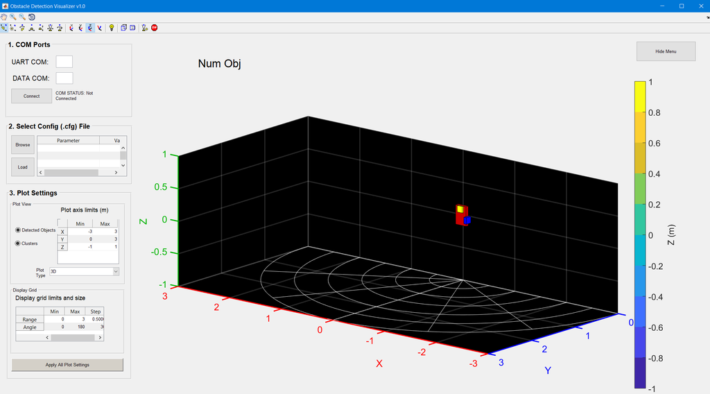

To start the radar chirp processing, perform the following steps:

- Fill in the two COM port numbers, then click the “Connect” button.
- Browse to the provided configuration file: `<TOOLBOX_INSTALL_DIR>\source\ti\examples\Automotive_Body_Sensors\obstacle_detection\chirp_configs\ods_default_config.cfg`.
- Click the “Load” button.
- The visualizer will now begin displaying detected objects and clusters.

To modify the display, the widgets in the “Plot Settings” window can be modified:

- The “Detected Objects” and “Clusters” buttons can be clicked at any time to enable/disable their display.
- To change the display from 3D to a 2D projection, open the “Plot Type” drop-down menu, make a selection, then click the “Apply All” button.
- To change the overall display limits, modify the values in “Plot axis limits” and click the “Apply All” button.
- To change the grid limits, modify the values in “Display grid limits and size” and click the “Apply All” button.

To modify the rendered image orientation and size:

- Select one of the icons shown here, then drag the mouse either up/down or left/right over the image. If you hover over an icon, a message will tell you what the button does. The button shown here in blue allows the size of the image to change. Drag the mouse up over the image (with the left button down) to increase the size, and down to decrease the size.

[figure not shown]

## 5. Understanding the Output

By default, detected objects and clusters are displayed. Detected objects are shown as dots in the 3D space, and clusters are shown as boxes. Cluster box sizes are obtained from the DSP’s clustering algorithm. Detected objects are updated at the configured frame rate, and clusters are updated at a slower rate, typically once every four frames. Note that detected objects and clusters can be disabled from being output from the EVM. This is enabled in the “guiMonitor” command, discussed in the “Visualizer Source Files” section below.

First, there is a banner line over the plot area. This banner displays the current frame number, the number of detected objects for the frame, and the number of clusters for the current frame. The number in parentheses is the number of clusters that are derived from a single point.

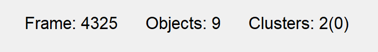

The detected object (dot) colors are determined by their Z distance (height) from the antenna. Cluster colors are red if the center is within 1 meter of the antenna, and green if outside 1 meter.

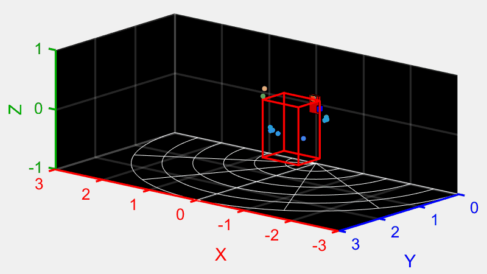

Each 2D display shows a flat projection along two of the three planes. Shown here is the “top-down” display that shows objects and clusters in the X-Y plane. Object point colors are still rendered according to Z position:

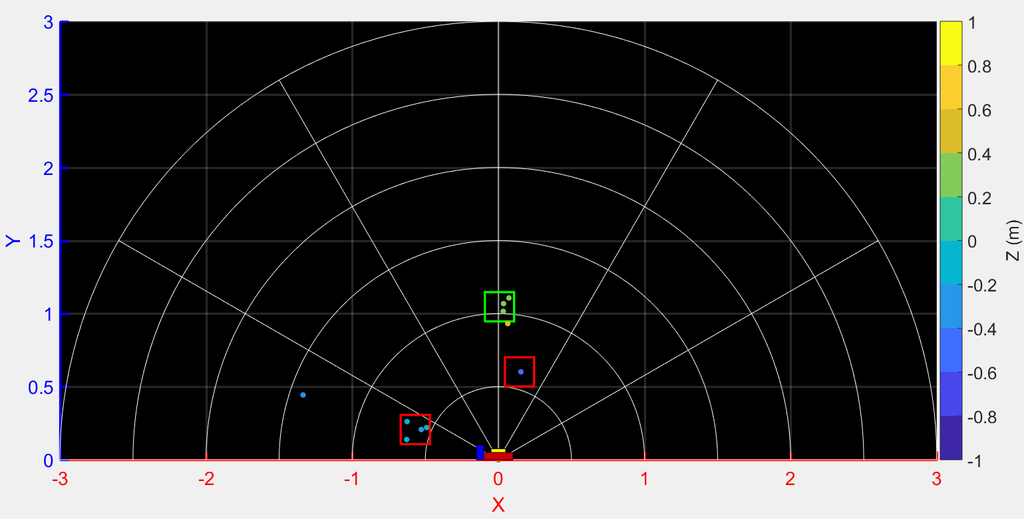

# Developer’s Guide

## Building the Firmware from Source Code

### 1. Prerequisites for Firmware

> 🛑 The software prerequisites must be met before continuing!

To verify proper installations, navigate to **`C:\ti`** and ensure that the following tools have been installed in the *EXACT* directory specified.

[output not shown]

### 2. Import Lab Project

For the Obstacle Detection lab there are two projects, the DSS for the C674x DSP core and the MSS project for the R4F core. Both need to be imported to CCS and compiled to generate firmware for the xWR1642.

- Start CCS and setup workspace as desired.
- Import the projects below to CCS using either TI Resource Explorer in CCS or CCS Import Projectspecs method:
  - **odsdemo_16xx_dss**
  - **odsdemo_16xx_mss**

> When importing projects to a workspace, a copy is created in the workspace. All modifications will only be implemented for the workspace copy. The original project downloaded from the Toolbox is not touched.

### 3. Build the Lab

#### **Build DSS Project**

The DSS project must be built before the MSS project.

> ⚠️ The DSS project must be built using compiler version 8.1.3.  
> To check the build settings, select **odsdemo_16xx_dss** and right click on the project to select **Show build settings…**. Under the **General** tab, the **Advanced Settings** section has a drop down menu for **Compiler Version**. Ensure that it reads **TI v8.1.3**.

With the **odsdemo_16xx_dss** project selected in **Project Explorer**, right click on the project and select **Rebuild Project**. Selecting **Rebuild** instead of **Build** ensures that the project is always re-compiled. This is especially important in case the previous build failed with errors.

> **Successful DSS Project Build** In the **Project Explorer** panel, navigate to and expand **odsdemo_16xx_dss > Debug** directory. The project has been successfully built if the following files appear in the **Debug** folder:
> - odsdemo_16xx_dss.bin
> - odsdemo_16xx_dss.xe674

#### **Build MSS Project**

After the DSS project is successfully built, select **odsdemo_16xx_mss** in **Project Explorer**, right click on the project and select **Rebuild Project**.

> **Successful MSS Project Build** In the **Project Explorer** panel, navigate to and expand **odsdemo_16xx_mss > Debug** directory. The project has been successfully built if the following files appear in the **Debug** folder:
> - odsdemo_16xx_mss.bin
> - odsdemo_16xx_mss.xer4f
> - odsdemo_16xx.bin

> ⚠️ *Build Fails with Errors*  
> If the build fails with errors, please ensure that all the prerequisites are installed as mentioned in the mmWave SDK release notes.

### 4. Execute the Lab

There are two ways to execute the compiled code on the EVM:

- Deployment mode: the EVM boots autonomously from flash and starts running the bin image
  - Using Uniflash, flash the **odsdemo_16xx.bin** found at `<PROJECT_WORKSPACE_DIR>\odsdemo_16xx_mss\Debug\odsdemo_16xx.bin`
  - The same procedure for flashing can be use as detailed in the Quickstart Flash the Device section.
- Debug mode: enables connection with CCS while lab is running; useful during development and debugging

For more information on using CCS Debug, refer to the documentation here

After starting the lab on the AWR1642 using either method, the program will wait until a chirp configuration is sent to it via the “User” COM port.

## Visualizer Source Files

> ⚠️ Working with and running the visualizer source files requires a full MATLAB license not just the MATLAB Runtime Engine

The detection processing chain is implemented in the C674x DSP core of the AWR1642 device. The visualizer serves to read the UART stream from the device and plots the detected objects and cluster information.

Source files are located at `<TOOLBOX_INSTALL_DIR>\tools\visualizers\Automotive_Obstacle_Detection_GUI`.

- **ods_3d_visualizer.m**: the Matlab gui program which reads and parses the UART data for visualization.
- **ods_3d_visualizer.exe**: the DOS executable version of the gui program.

Chirp Configuration files are located at `<TOOLBOX_INSTALL_DIR>\source\ti\examples\Automotive_Body_Sensors\obstacle_detection\chirp_configs`. In addition to the normal mmWave chirp configuration CLI commands, there are a few commands that are specific to the Obstacle Detection Demo:

[output not shown]

Please refer to the mmWave SDK’s user guide for details on the chirp (RF) related CLI configuration commands.

## Data Packet Format

A TLV(type-length-value) encoding scheme is used with little endian byte order. For every frame, a packet is sent consisting of a fixed sized **Frame Header** and then a variable number of TLVs depending on what was selected via the guiMonitor command. There are 4 possible TLV types for the Obstacle Detection demo:

| TLV Name | Type | Data Size (bytes) |
| --- | --- | --- |
| Detected Objects | 1 | 4 + (12 x numDetObj) |
| Clusters | 2 | 4 + (12 x numClusters) |
| Range Azimuth Heatmap | 3 | 60 x Yr x sizeof(float) |
| Range Elevation Heatmap | 4 | 60 x Yr x sizeof(float) |

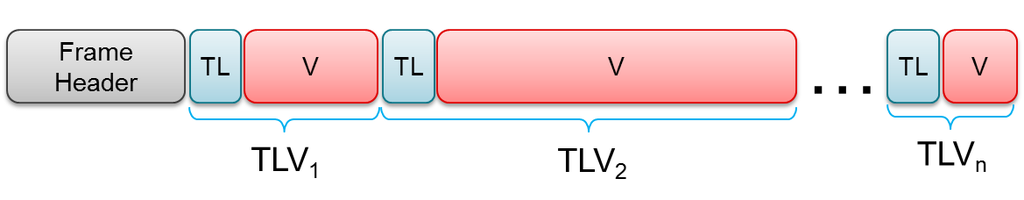

### Frame Header

Size: 40 bytes

```matlab
frameHeaderStructType = struct(...
    'sync',             {'uint16', 8}, ... % syncPattern in hex is: '02 01 04 03 06 05 08 07'
    'version',          {'uint32', 4}, ... % 0xA1642 or 0xA1443
    'totalPacketLen',   {'uint32', 4}, ... % In bytes, including the header
    'platform',         {'uint32', 4}, ... % See description below
    'frameNumber',      {'uint32', 4}, ... % Starting from 1
    'timeCpuCycles',    {'uint32', 4}, ... % Time in DSP cycles when the message was created
    'numDetectedObj',   {'uint32', 4}, ... % number of detected objects
    'numTLVs' ,         {'uint32', 4}, ... % Number of TLVs in this message
    'subFrameIndex',    {'uint32', 4});    % always zero
```

### TLVs

TLVs in this demo can be of type **DETECTED_OBJECTS**, **CLUSTERS**, **RANGE_AZIMUTH_HEAT_MAP**, or **RANGE_ELEV_HEAT_MAP**. Each TLV consists of a TLV header plus a unique data type.

#### **TLV Header**

Size: 8 bytes

```matlab
% TLV Type: 01 = DetectedObjects, 02 = Clusters, 03 = RangeAzimuthHeatmap, 04 = RangeElevHeatmap
tlvHeaderStruct = struct(...
    'type',             {'uint32', 4}, ... % TLV object
    'length',           {'uint32', 4});    % TLV object Length, in bytes, including TLV header
```

Following the header are the TLV-type specific payloads

#### **Detected Objects TLV**

Type: DETECTED_OBJECTS

Size: 4 + (12 x numDetObj)

The following structure is only present if the TLV header.length is greater than zero.

```java
featureVector = struct(...
    'numDetObj',  {'short', 2}, ... % Number of detected objects in the following sub-struct
    'xyzQFormat', {'short', 2}, ... % Q-point shift value to convert to meters
      %per object:
      'speedIdx', {'short', 2}, ... % Doppler index
      'x',        {'short', 2}, ... % x - coordinate in meters, divided by xyzQFormat
      'y',        {'short', 2}, ... % y - coordinate in meters, divided by xyzQFormat
      'z',        {'short', 2}, ... % z - coordinate in meters, divided by xyzQFormat
      'rangeIdx', {'short', 2}, ... % Range index
      'peakVal',  {'short', 2}, ... % Peak value
```

#### **Cluster TLV**

Type: CLUSTERS

Size: 4 + (12 x numClusters)

The following structure is only present if the TLV header.length is greater than zero. Note that cluster size can be adjusted by the “max distance” parameter of **dbscanCfg**.

```java
featureVector = struct(...
    'numClusters',{'short', 2}, ... % Number of clusters in the following sub-struct
    'xyzQFormat', {'short', 2}, ... % Q-point shift value to convert to meters
      %per cluster:
      'x',        {'short', 2}, ... % x - coordinate in meters, divided by xyzQFormat
      'y',        {'short', 2}, ... % y - coordinate in meters, divided by xyzQFormat
      'z',        {'short', 2}, ... % z - coordinate in meters, divided by xyzQFormat
      'xsize',    {'short', 2}, ... % x size of the cluster, in meters, by xyzQFormat
      'ysize',    {'short', 2}, ... % y size of the cluster, in meters, by xyzQFormat
      'zsize',    {'short', 2}, ... % z size of the cluster, in meters, by xyzQFormat
```

> The two ODS heatmaps are 2D array of floats, and will be the same size based on the current configuration. The size of the row is currently hardcoded in the target code and visualizer to be 180 degrees divided by the angular or elevation resolution, currently 3 degrees. So each row contains 60 points, and the row corresponds to a range from the antenna. The number of rows, Yr, is calculated by both the target code and visualizer code, based on the **profileCfg** and **cfarCfg** commands in the configuration file. First, the range resolution (in meters) is calculated from **profileCfg**, then the max detection range in **cfarCfg** is divided by the range resolution to obtain the number of range rows.

#### **Range Azimuth Heatmap TLV**

Type: RANGE_AZIMUTH_HEAT_MAP

Size: 60 x Yr x sizeof (float)

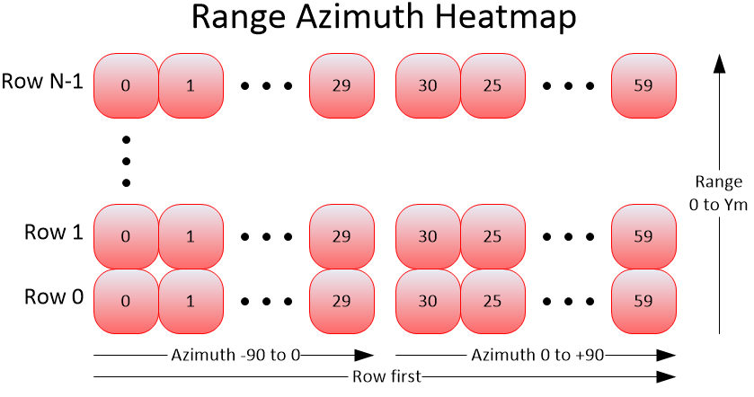

#### **Range Elevation Heatmap TLV**

Type: RANGE_ELEV_HEAT_MAP

Size: 60 x Yr x sizeof (float)

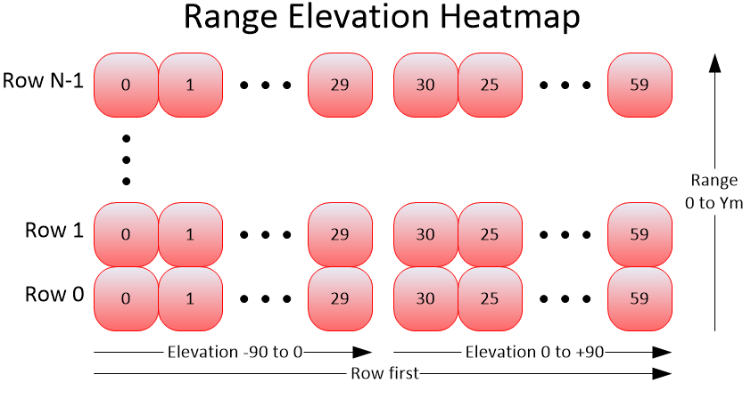

# Need More Help?

- Find more details about ODS by referring to the [ODS TI Design document](http://www.ti.com/tool/TIDEP-0104)
- Find answers to common questions on [mmWave E2E FAQ](https://e2e.ti.com/support/sensor/mmwave_sensors/w/wiki)
- Search for your issue or post a new question on the [mmWave E2E forum](https://e2e.ti.com/support/sensor/mmwave_sensors/f/1023)